# JSC370 Final Project

2023-03-10

# Introduction

Happiness is a viral topic in the modern world, as it is ultimately what everyone longs for. However, according to the World Health Organization, 1 in 8 people suffer from mental disorders, and there has been a 25% increase in depression after COVID-19. With this, I am prompted to know more about how happiness has progressed overtime and the factors that influence it. For instance, in the academic researcher, Satoshi Kanazawa’s paper, “Sunshine on my shoulders makes me happy… especially if I’m less intelligent: how sunlight and intelligence affect happiness in modern society”, he discovers that darkness induces fear and anxiety while exposure to sunlight increases happiness. Not only do I want to explore the effect of sunshine hours, I am also interested in other factors, such as economic status and freedom in a country.

Perhaps, with this report, I hope to provide insights to government policies or personal actions that can help improve the well-being of individuals. Therefore, combining these motivations, I hope to look at happiness from three different aspects, physiological needs (economic status), regional factors (sunshine), and emotional needs (freedom, love). My question of interest is “Do people get happier overtime? Does economic status, freedom to make life choices, and sunshine hours affect people’s happiness?”.

My first data set is retrieved from a renown source, [World Happiness Report](https://worldhappiness.report/), which is a report written by members of the United Nations Sustainable Development Solutions Network. It makes use of the “Gallup World Poll”, a global survey data that consists of over 100 questions including regional specific questions. The report provides insights in how people evaluate their own lives by country. The data set I will be using has records starting from 2005 to 2021, where the happiness score - the national average response to the question of measuring oneself on life ladders - is recorded for more than 150 countries worldwide. Other variables I will be using from the data set are log GDP per capita obtained from World Development Indicators, and the freedom to make life choices and perceptions of corruption, results obtained from Gallup World Poll.

The second data set is retrieved from [Wikipedia](https://en.wikipedia.org/wiki/List_of_cities_by_sunshine_duration), which contains a list of sunshine hours for 391 cities, including the yearly and monthly duration. Records of this data set are compiled from numerous sources.

The third data set I utilized is a world cities data retrieved from [SimpleMaps](https://simplemaps.com/data/world-cities) which contains information, such as the population and geographical information (latitude and longitude) for over 40k cities worldwide. This data set is compiled from numerous reliable sources, which includes NASA, National Geospatial-Intelligence Agency, U.S. Census Bureau, and U.S. Geological Survey. This data set will specifically be used with the sunshine data set to find which cities are a better representation for the country.

# Methods

## Data Collection

The happiness data set is downloaded from the [World Happiness Report](https://worldhappiness.report/ed/2022/#appendices-and-data) website. The process is as easy as a simple download for “Data for Table 2.1”, which is downloaded as an excel file. I later converted to a csv myself.

The second data set uses the “rvest” package from R to perform web scraping from Wikipedia; it uses the URL to read HTML code and CSS selectors to subsequently scrape the table.

The cities census data set is retrieved from [SimpleMaps](https://simplemaps.com/data/world-cities), which is available for download in csv or excel format.

## Data Wrangling & Cleaning

This is a sample table of the sunshine data set; it contains the sunshine hours for 391 cities.

Table 1: Data from Wikipedia Sunshine Hours

| Country | City | Jan | Feb | Mar | Apr | May | Jun | Jul | Aug | Sep | Oct | Nov | Dec | Year | Ref. |
| --- | --- | --- | --- | --- | --- | --- | --- | --- | --- | --- | --- | --- | --- | --- | --- |
| Ivory Coast | Gagnoa | 183 | 180.0 | 196.0 | 188.0 | 181.0 | 118.0 | 97.0 | 80.0 | 110.0 | 155.0 | 171 | 164.0 | 1,823.0 | [2] |
| Ivory Coast | Bouaké | 242 | 224.0 | 219.0 | 194.0 | 208.0 | 145.0 | 104.0 | 82.0 | 115.0 | 170.0 | 191 | 198.0 | 2,092.0 | [2] |
| Ivory Coast | Abidjan | 223 | 223.0 | 239.0 | 214.0 | 205.0 | 128.0 | 137.0 | 125.0 | 139.0 | 215.0 | 224 | 224.0 | 2,296.0 | [2] |
| Ivory Coast | Odienné | 242 | 220.2 | 217.3 | 214.7 | 248.8 | 221.8 | 183.5 | 174.5 | 185.4 | 235.8 | 252 | 242.6 | 2,638.6 | [3] |
| Ivory Coast | Ferké | 279 | 249.0 | 253.0 | 229.0 | 251.0 | 221.0 | 183.0 | 151.0 | 173.0 | 245.0 | 261 | 262.0 | 2,757.0 | [2] |

I checked for null values in the sunshine data set and discovered that the data set is free of null values. I then converted the yearly sunshine duration from characters to numeric data. I also checked for abnormal values. For instance, I checked the locations of maximum and minimum yearly sunshine in the data set, which appear in Yuma, United States, and Tórshavn, Faroe Islands, respectively. I validated that both of these observations are accurate. To prepare for merging, since sunshine hours are reported by cities, while our happiness data set is reported in countries, I created a new data frame that records mean yearly sunshine, maximum yearly sunshine, minimum yearly sunshine for each country.

Below is a sample table of the happiness data set.

Table 2: Data from World Happiness Report

| Country.name | year | Life.Ladder | Log.GDP.per.capita | Social.support | Healthy.life.expectancy.at.birth | Freedom.to.make.life.choices | Generosity | Perceptions.of.corruption | Positive.affect | Negative.affect |
| --- | --- | --- | --- | --- | --- | --- | --- | --- | --- | --- |
| Afghanistan | 2008 | 3.724 | 7.370 | 0.451 | 50.80 | 0.718 | 0.168 | 0.882 | 0.518 | 0.258 |
| Afghanistan | 2009 | 4.402 | 7.540 | 0.552 | 51.20 | 0.679 | 0.190 | 0.850 | 0.584 | 0.237 |
| Afghanistan | 2010 | 4.758 | 7.647 | 0.539 | 51.60 | 0.600 | 0.121 | 0.707 | 0.618 | 0.275 |
| Afghanistan | 2011 | 3.832 | 7.620 | 0.521 | 51.92 | 0.496 | 0.162 | 0.731 | 0.611 | 0.267 |
| Afghanistan | 2012 | 3.783 | 7.705 | 0.521 | 52.24 | 0.531 | 0.236 | 0.776 | 0.710 | 0.268 |

There are 36 NA values in log GDP per capita and 32 NA values in the “Freedom.to.make.life.choices” variable, which I removed. 68 observations were removed in total and 1881 observations remaining. The happiness dataset is very well compiled; the data set is free from abnormal values. As an extra validation, I checked whether freedom scores are between 0 and 1 and whether the GDP is between an acceptable range. I also checked whether there were distinct or duplicated happiness scores for the same country in the same year.

Before merging the two data sets, I checked the number of country names that are found in both data sets. I recognized that some countries, such as Hong Kong and Taiwan are named differently, so I changed these names in the sunshine data to match the names in the happiness data.

There are a total of 44691 observations in this data set, and 307 of which have empty entries for the population column.

## Data Merging - Sunshine Hours Data & World Cities Data

As I have mentioned previously, the sunshine data set only contains sunshine hours for cities specifically; however, the happiness data is only recorded by country. Therefore, we need to obtain the country sunshine hours. There are many ways to do this, such as averaging the sunshine hours over all cities within the country or choose a deciding factor for which cities are a better representation for the country. I chose “population” to be the deciding factor, since in my opinion, higher population means that more people in this country are receiving this amount of sunshine hours.

Prior to merging the sunshine data set with the world cities population data set, one major modification required within the world cities data set are to match the city names. Some of them do not match that of the sunshine data set. Some changes I made include changing “Viljandi” to “Vilsandi” in the sunshine, “Luxembourg” to “Luxembourg City”, and “New York” to “New York city” in the world cities data. Other name changes were also required when there were special language characters in city names, such as “Montréal” and “Kolkāta”. Moreover, I changed a couple of country names. For example, I imputed the country for “Macau” which was empty previously, and changed “Saint Pierreand Miquelon” in the sunshine data set to be free of typos. One special case is “Tel Aviv” which was recorded as a city in the sunshine but a capital in the world cities data set. Therefore, to calculate the population, I summed up all population in the Tel Aviv first. A total of 30 cities were modified to prepare for merging.

After merging, I realized that there are still 28 cities that do not have population records. For cities whose country is not present in the happiness data set or cities which are in countries that already have cities with population records, it will not be a problem to obtain the max populated cities. There were only 2 countries remaining that require imputation, “Ivory Coast” and “North Macedonia”, which are both not in the world cities data set. Therefore, I chose Abidjan and Skopje as the cities to represent sunshine hours after learning they are the capitals in “Ivory Coast” and “North Macedonia” respectively.

Table 4: Country Sunshine Data by Highest Populated cities

| Country.name | City | Jan | Feb | Mar | Apr | May | Jun | Jul | Aug | Sep | Oct | Nov | Dec | Avg_sunshine |
| --- | --- | --- | --- | --- | --- | --- | --- | --- | --- | --- | --- | --- | --- | --- |
| Afghanistan | Kabul | 177.2 | 178.6 | 204.5 | 232.5 | 310.3 | 353.4 | 356.8 | 339.7 | 303.9 | 282.6 | 253.2 | 182.4 | 3175.1 |
| Albania | Tirana | 124.0 | 125.0 | 165.0 | 191.0 | 263.0 | 298.0 | 354.0 | 327.0 | 264.0 | 218.0 | 127.0 | 88.0 | 2544.0 |
| Algeria | Algiers | 149.0 | 165.0 | 202.0 | 258.0 | 319.0 | 318.0 | 350.0 | 319.0 | 237.0 | 229.0 | 165.0 | 136.0 | 2847.0 |
| Angola | Luanda | 219.0 | 208.0 | 213.0 | 199.0 | 233.0 | 223.0 | 175.0 | 150.0 | 145.0 | 164.0 | 199.0 | 212.0 | 2341.0 |
| Argentina | Buenos Aires | 279.0 | 240.8 | 229.0 | 220.0 | 173.6 | 132.0 | 142.6 | 173.6 | 189.0 | 227.0 | 252.0 | 266.6 | 2525.2 |

## Data Merging - Happiness Data and Sunshine Data

After merging the data set, I discovered that there are still around 30 countries out of 161 countries which do not have sunshine hours reported. After carefully examining these countries, I recognized that they are less renown countries in the world; therefore, I decided to safely remove them from the merged data set. I also removed the columns that are not my variables of my interest, such as generosity, social support, positive effect … etc. I renamed the columns to a more accessible format as well. My final merged data set consists of 1553 observations, and below is a sample table.

Table 3: Merged Data from World Happiness Report and Sunshine Hours Data

| Country | Year | Happiness | Log_GDP | Freedom | Jan | Feb | Mar | Apr | May | Jun | Jul | Aug | Sep | Oct | Nov | Dec | Avg_sunshine |
| --- | --- | --- | --- | --- | --- | --- | --- | --- | --- | --- | --- | --- | --- | --- | --- | --- | --- |
| Afghanistan | 2018 | 2.694 | 7.692 | 0.374 | 177.2 | 178.6 | 204.5 | 232.5 | 310.3 | 353.4 | 356.8 | 339.7 | 303.9 | 282.6 | 253.2 | 182.4 | 3175.1 |
| Afghanistan | 2008 | 3.724 | 7.370 | 0.718 | 177.2 | 178.6 | 204.5 | 232.5 | 310.3 | 353.4 | 356.8 | 339.7 | 303.9 | 282.6 | 253.2 | 182.4 | 3175.1 |
| Afghanistan | 2012 | 3.783 | 7.705 | 0.531 | 177.2 | 178.6 | 204.5 | 232.5 | 310.3 | 353.4 | 356.8 | 339.7 | 303.9 | 282.6 | 253.2 | 182.4 | 3175.1 |
| Afghanistan | 2011 | 3.832 | 7.620 | 0.496 | 177.2 | 178.6 | 204.5 | 232.5 | 310.3 | 353.4 | 356.8 | 339.7 | 303.9 | 282.6 | 253.2 | 182.4 | 3175.1 |
| Afghanistan | 2017 | 2.662 | 7.697 | 0.427 | 177.2 | 178.6 | 204.5 | 232.5 | 310.3 | 353.4 | 356.8 | 339.7 | 303.9 | 282.6 | 253.2 | 182.4 | 3175.1 |

## Data Exploration

I checked the distributions of each variable by plotting the respective histograms. I recognized that freedom is left-skewed, which means that the data is a better representation for countries with more freedom. Happiness score is normally distributed, which a good indication that one of the assumptions for linear regression is satisfied. As for average sunshine hours, it holds a bimodal distribution with the two peaks at around 1800 and 3000 hours. There are two explanations for this: countries with 1800 and 3000 yearly sunshine duration participate in the happiness report for a lot of the years, or there are more countries with 1800 and 3000 yearly sunshine hours.

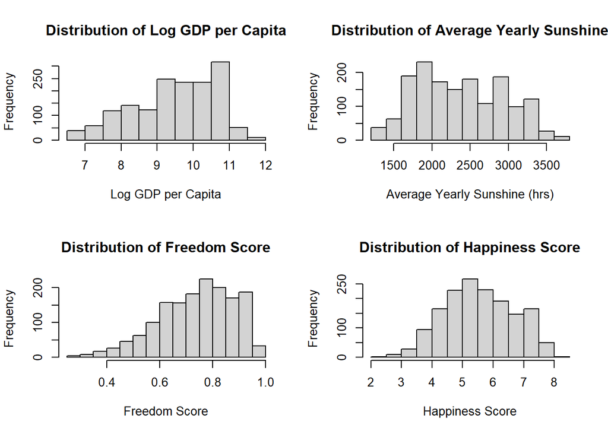

I also used the pairs plot function in R to explore the relationship between each of the variables and detect for possible linear relationships. As a result, I recognized that there are potential linear relationships between the variables Happiness and log GDP in particular.

[figure not shown]

In addition, I realized that not every country was recorded the same number of times in the data set. This may cause a biased resultof the mean GDP or happiness score for each year, and this is something to keep in mind, which I will address later.

Table 5: Number of Countries Participated in Happiness Report Each Year

| Year | 2005 | 2006 | 2007 | 2008 | 2009 | 2010 | 2011 | 2012 | 2013 | 2014 | 2015 | 2016 | 2017 | 2018 | 2019 | 2020 |
| --- | --- | --- | --- | --- | --- | --- | --- | --- | --- | --- | --- | --- | --- | --- | --- | --- |
| Countries Reported | 25 | 69 | 84 | 90 | 92 | 101 | 117 | 116 | 111 | 113 | 114 | 116 | 120 | 114 | 114 | 79 |

# Preliminary Analysis

### 1.

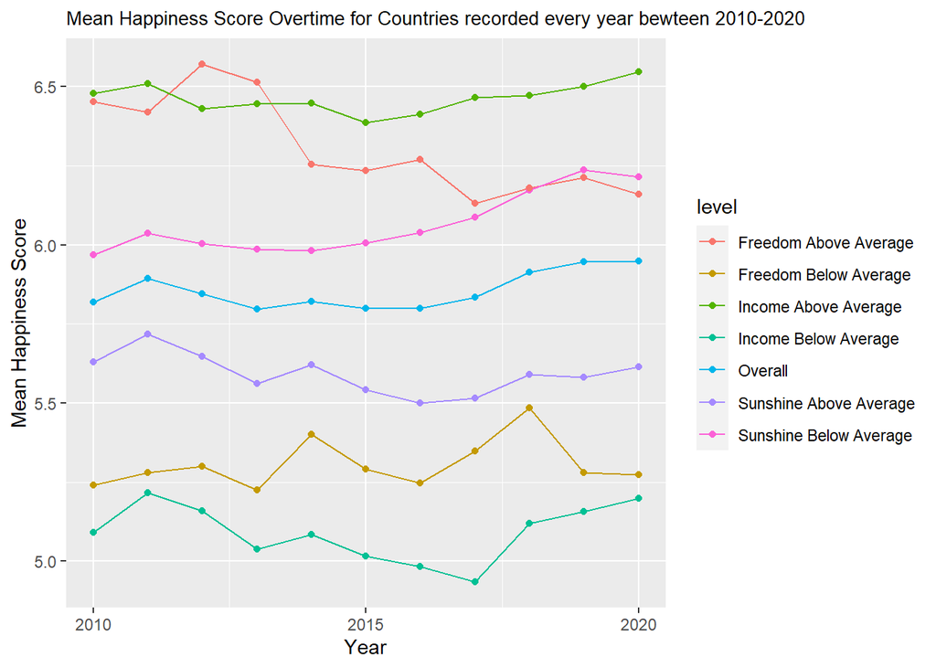

**Explanation:**

As mentioned previously, not every country is recorded every year between 2005 to 2020. Therefore, if we analyze the mean happiness score progression over time using all observations, there would be inaccurate results. For instance, the mean happiness score may increase because a country with high happiness score was added in the later years. Therefore, I chose to only report the mean happiness score for countries that participated in the Happiness report every year between 2010 to 2020. Furthermore, I separated the trend for mean happiness score into categories based on income levels (above or below average), freedom levels (above or below average), and sunshine hours (above or below average). An overall trend in mean happiness score for these countries without categorizing is also displayed.

### 2.

Table 6: Summary of GDP, Sunshine Hours, Freedom Score based on Happiness Frequency Grouping

| Happiness Frequency | Average Log GDP | Max Log GDP | Min Log GDP | Average Sunshine Hours | Max Sunshine Hours | Min Sunshine Hours | Average Freedom Score | Max Freedom Score | Min Freedom Score | # of Countries |
| --- | --- | --- | --- | --- | --- | --- | --- | --- | --- | --- |
| 1/3 to 2/3 | 9.799564 | 11.000 | 8.398 | 2229.037 | 3187.0 | 1754 | 0.7123397 | 0.954 | 0.369 | 12 |
| at least 2/3 | 10.328373 | 11.648 | 8.193 | 2168.550 | 3508.7 | 1230 | 0.8205863 | 0.985 | 0.458 | 52 |
| less than 1/3 | 8.621554 | 10.393 | 6.635 | 2568.144 | 3737.1 | 1618 | 0.6698748 | 0.952 | 0.258 | 63 |

**Explanation:**

This is a summary table done by categorizing countries by their levels of happiness. I define three categories for the countries based on the frequency of their happiness scores being greater or equal to the mean happiness score of the corresponding year. There are three groups in total: less than $\frac{1}{3}$, $\frac{1}{3}$ to $\frac{2}{3}$ , and at least $\frac{2}{3}$. The categories can be interpreted as follows: if a country appears in the less than $\frac{1}{3}$ category, this means that out of all the years the country participated in the World Happiness Report, less than $\frac{1}{3}$ of their records yielded a happiness scores higher or equal to the mean happiness of that same year.

As a result of the summary table, the category of “at least $\frac{2}{3}$” yields the highest average log GDP and average freedom score, whereas the highest average sunshine appears in the “less than $\frac{1}{3}$” category. Also, the maximum log GDP occurs in countries with at least $\frac{2}{3}$ being happy and the minimum occurs in the “less than $\frac{1}{3}$” category. This suggests that countries with higher GDP have higher happiness. A similar result applies on the factor freedom, which suggests that countries with higher freedom lead to more happiness. On the contrary, the category of “less than $\frac{1}{3}$” yields the maximum sunshine hours, while the minimum occurs in the “at least $\frac{2}{3}$” category. This allows us to say that sunshine hours doesn’t increase happiness, but perhaps decreases.

As a note, I used the maximum of maximum yearly sunshine and minimum of minimum yearly sunshine to record the maximum and minimum sunshine hours for each category, rather than the maximum and minimum values of average yearly sunshine.

### 3.

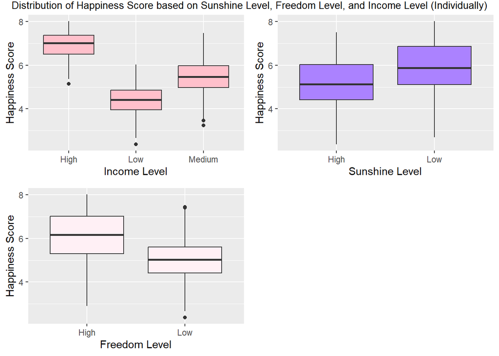

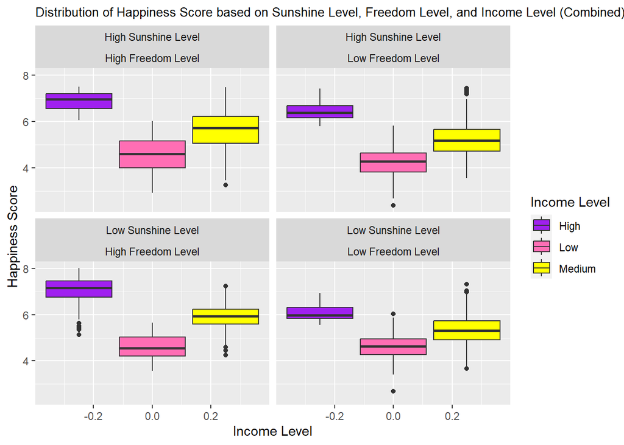

**Explanation:**

Income is separated into three levels: high, medium, and low. A “low” income indicates the log GDP per capita is less than or equal to the first quantile of log GDP per capita, whereas “medium” indicates that it lies between the first and third quantile, and “high” when it is above the third quantile. Freedom score and sunshine hours are classified into two groups by comparing with the mean values: high and low.

By inspecting the first plot, a high income level generally generates a higher average happiness score, and similarly for high freedom levels. As for sunshine levels, low sunshine levels typically yield a higher happiness score. The low freedom level group possesses a smaller interquartile range than that of the high freedom level group, meaning that its happiness scores has the least variations. Meanwhile, the variation between the high, medium, and low income group and the variation between the high and low sunshine level group is rather similiar. Moreover, there a few outliers with low happiness score in the high, medium, and low income, which suggests that there are still countries in each of these groups that possess a lower happiness score than the average.

### 4.

[figure not shown]

Table 7: Linear Model Coefficients with Siginficance

| Terms | Coefficient Estimate | Significance |
| --- | --- | --- |
| Intercept | -2.2981942 | Yes |
| Log GDP per capita | 0.6566894 | Yes |
| Freedom Score | 2.3985811 | Yes |
| Average Sunshine | 0.0000591 | No |

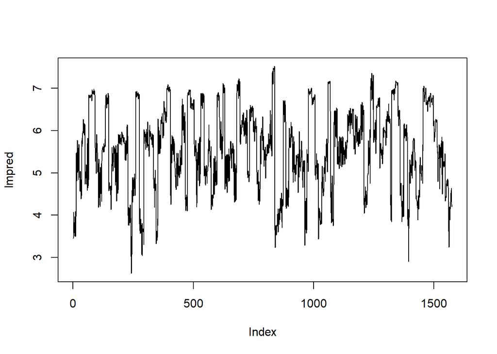

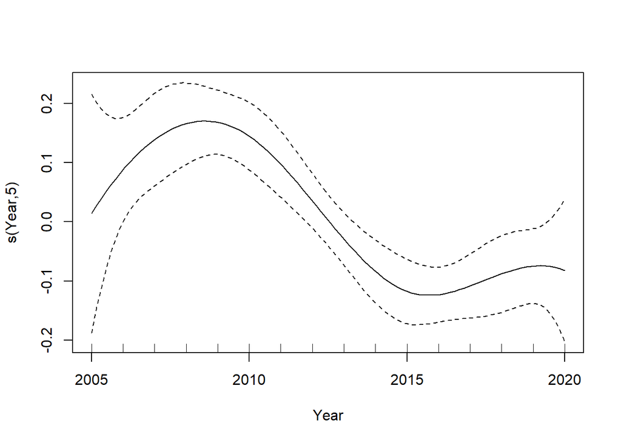

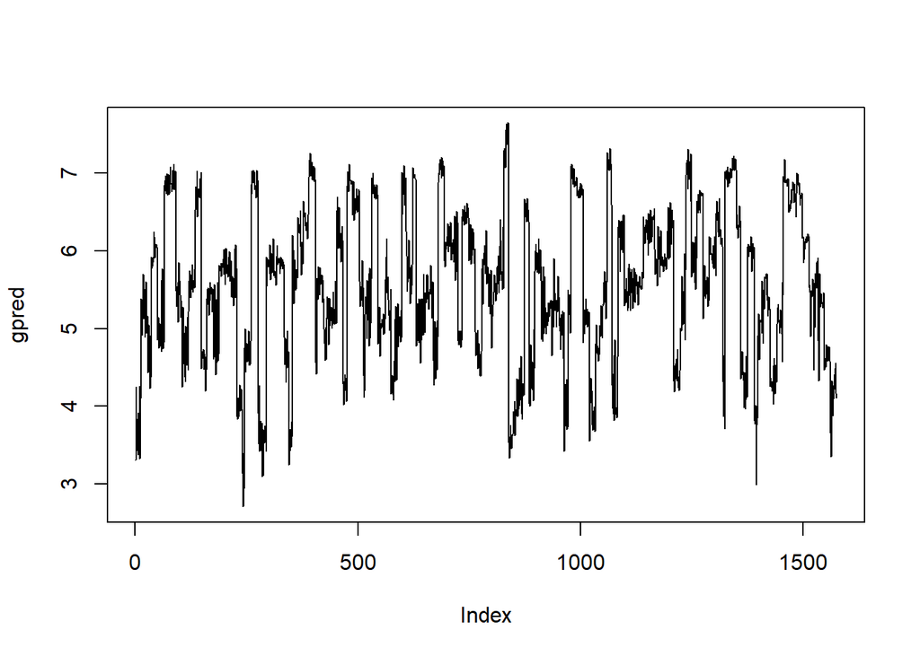

#### Bagging

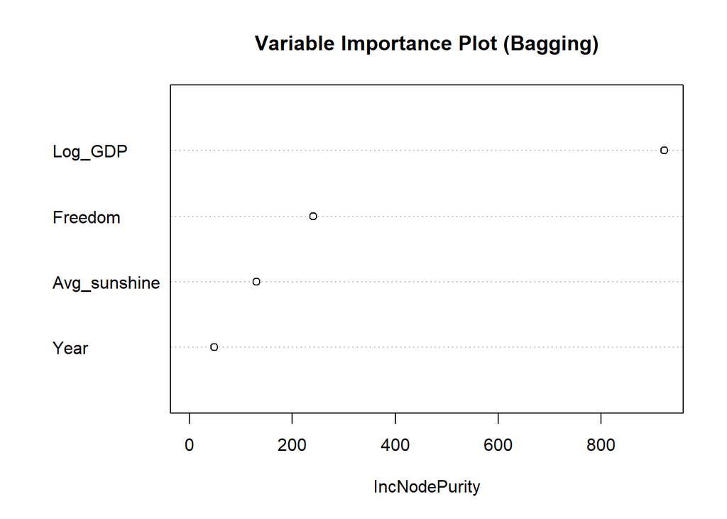

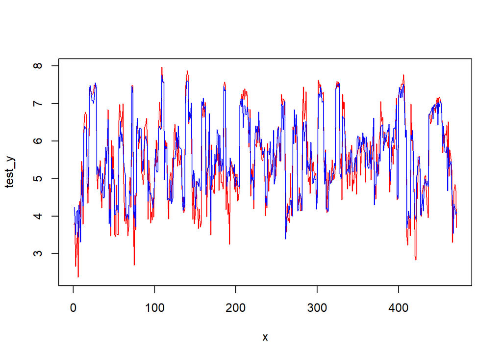

#### Random Forest

[figure not shown]

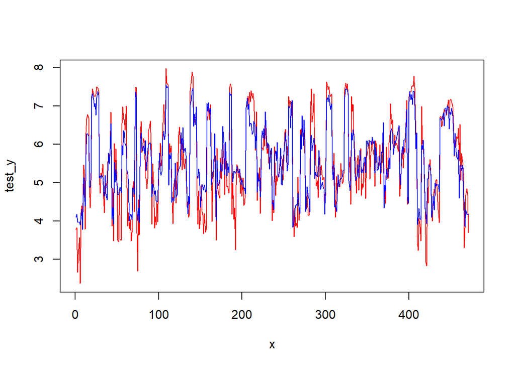

#### Boosting

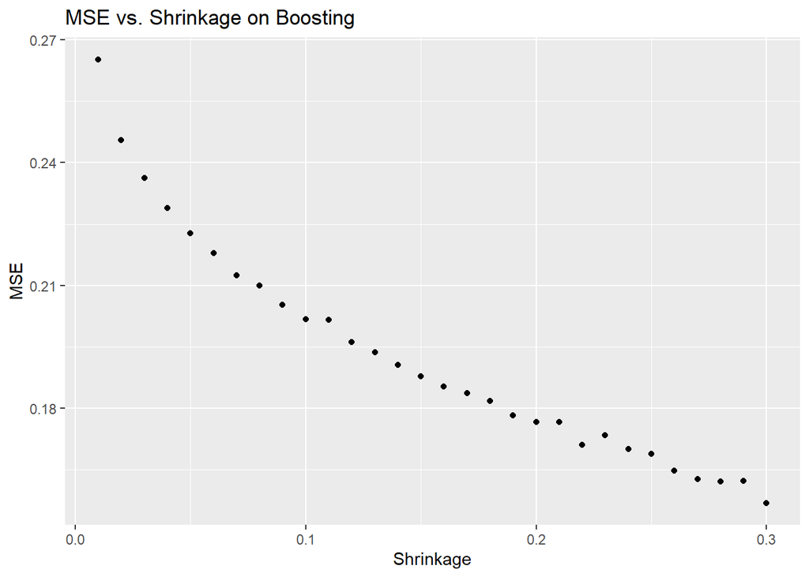

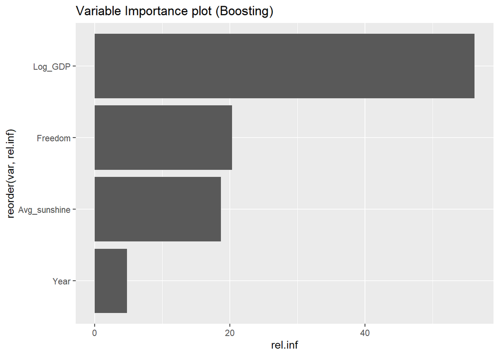

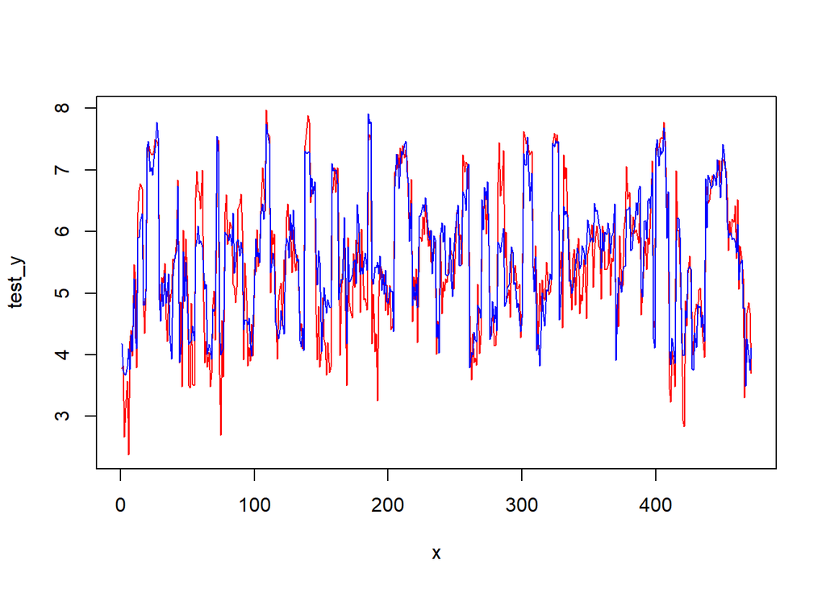

#### XG Boosting

realized that increasing the max depth doesn’t help from 9 onwards

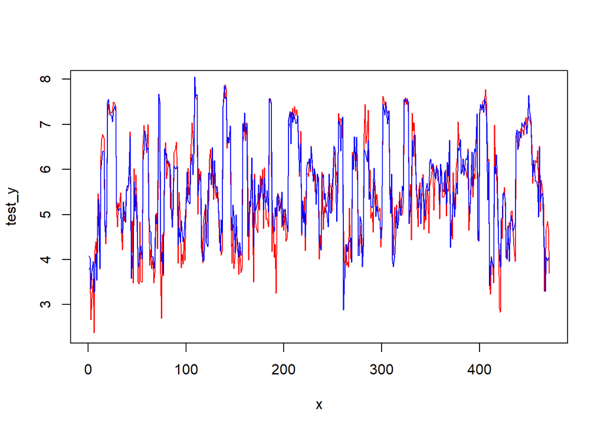

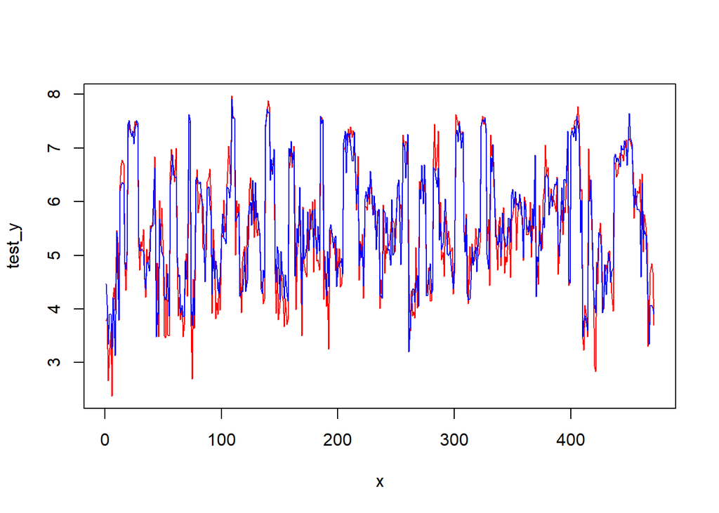

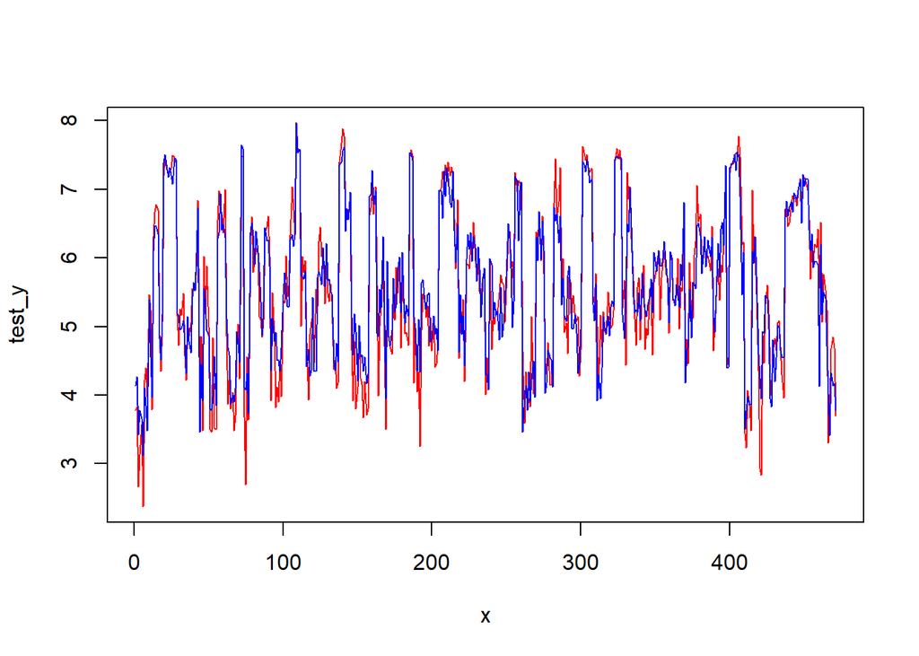

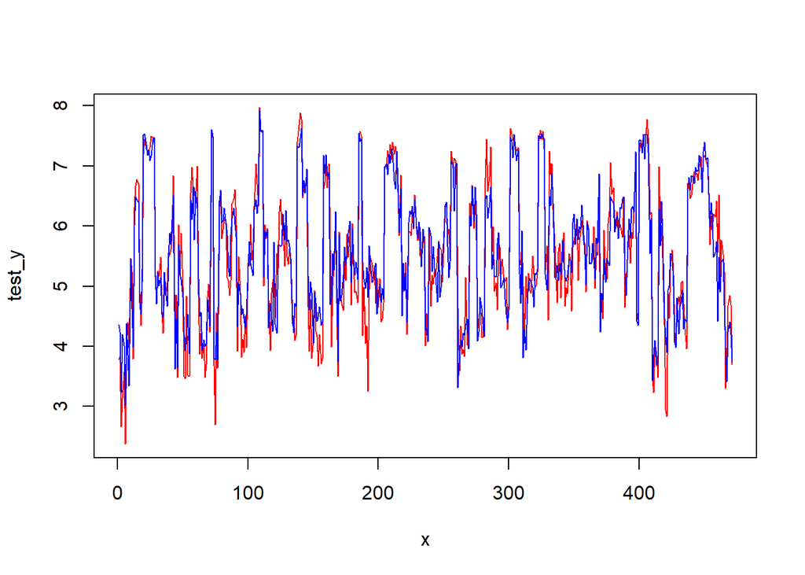